# Wine Quality Prediction Project

# Project Overview

```r
library(magrittr)

white_wine_dataset <- read.csv(here::here("data-raw", "winequality-white.csv"),
                               header = TRUE,
                               sep = ";")
```

# Data Preparation

```r
white_col_list <-
  colnames(white_wine_dataset[1:11]) %<>%
  gsub("[[:punct:]]", "_", .) %>%
  gsub("[[:space:]]", "_", .)

renamed_white_wine <-
  paste0(tolower(white_col_list))

white_wine_dataset %>%
  dplyr::rename_at(1:11, ~renamed_white_wine) %>%
  saveRDS(here::here("data", "white_wine_dataset.rds"))
```

# Objectives

We want to make a predictive model on the quality of **white wine** based on chemical properties of wine.

The following analytical approaches are taken:

- Multiple regression: the *Quality* response is assumed to be a continuous variable and is predicted by the independent predictors, all of which are continuous.
- Regression Tree
- Classification of wines based on the chemical properties: Unsupervised analysis
- Classification of wines based on the chemical properties: K-nearest neighbors classification

# Exploratory Data Analysis and Data Preprocessing

All white wine data set variables are summarized and univariate analysis with plots are shown.

## Histograms

We start with histograms to show the distribution of the variable values.

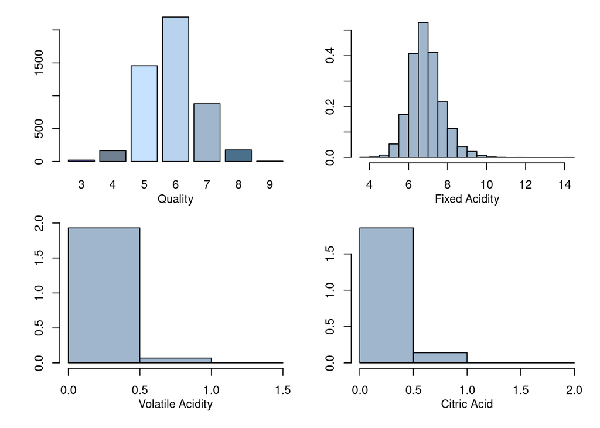

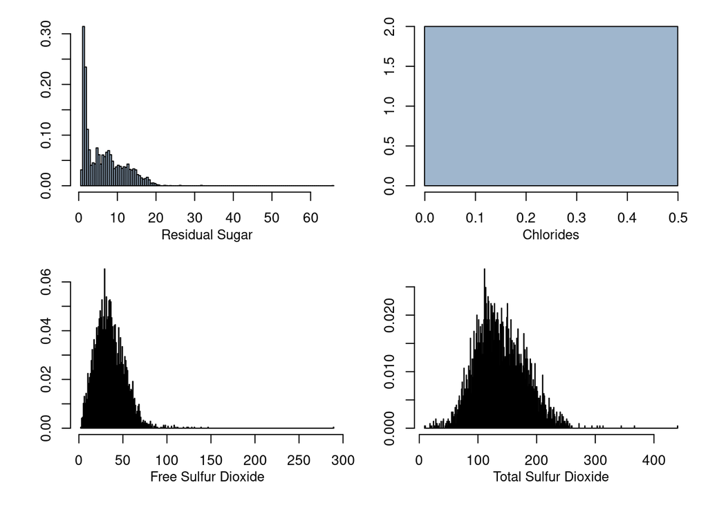

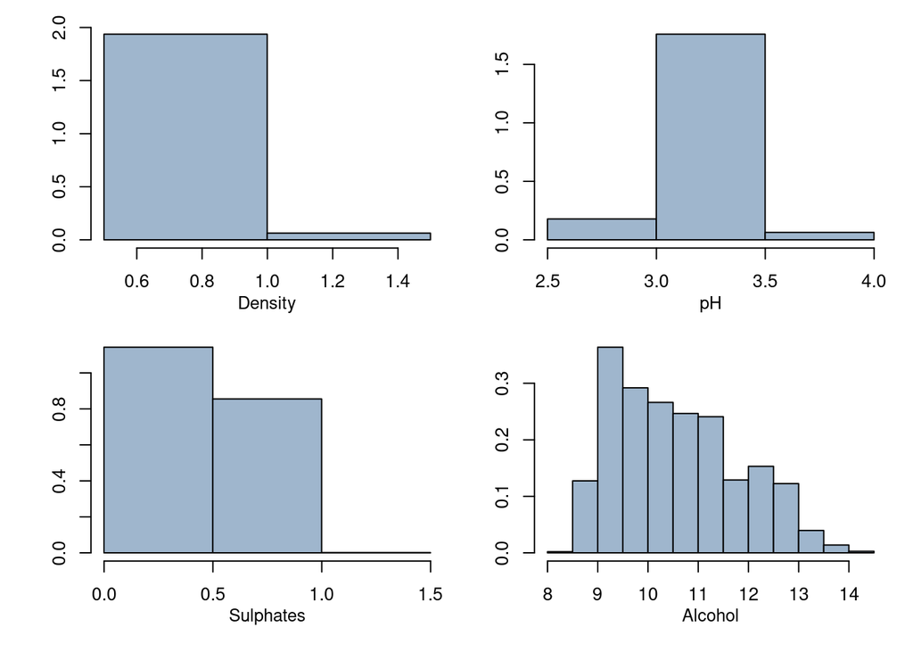

## Boxplots

We also utilize boxplots to get a different view of the spread.

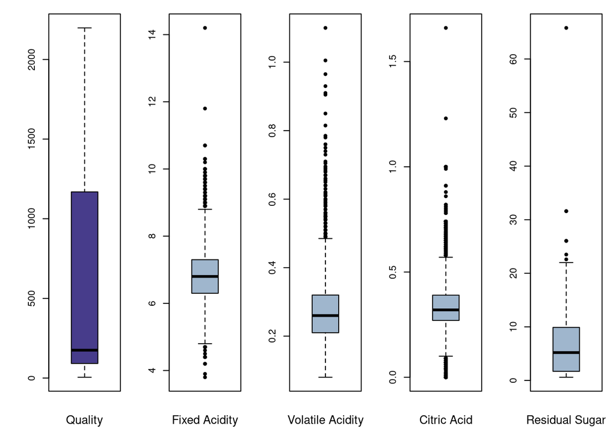

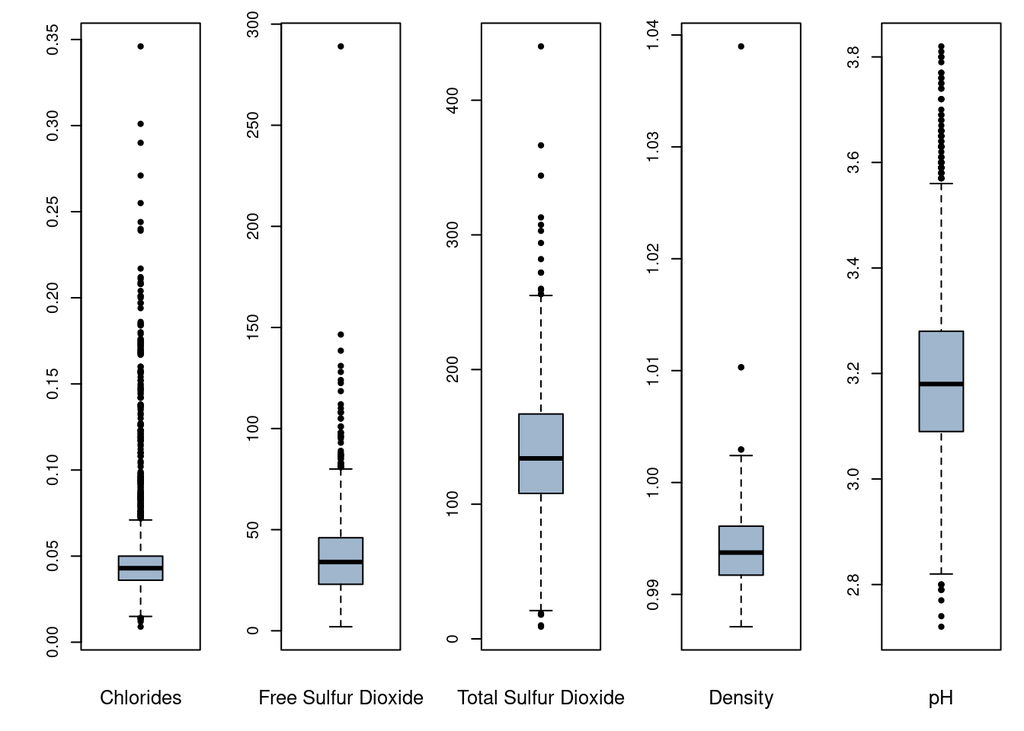

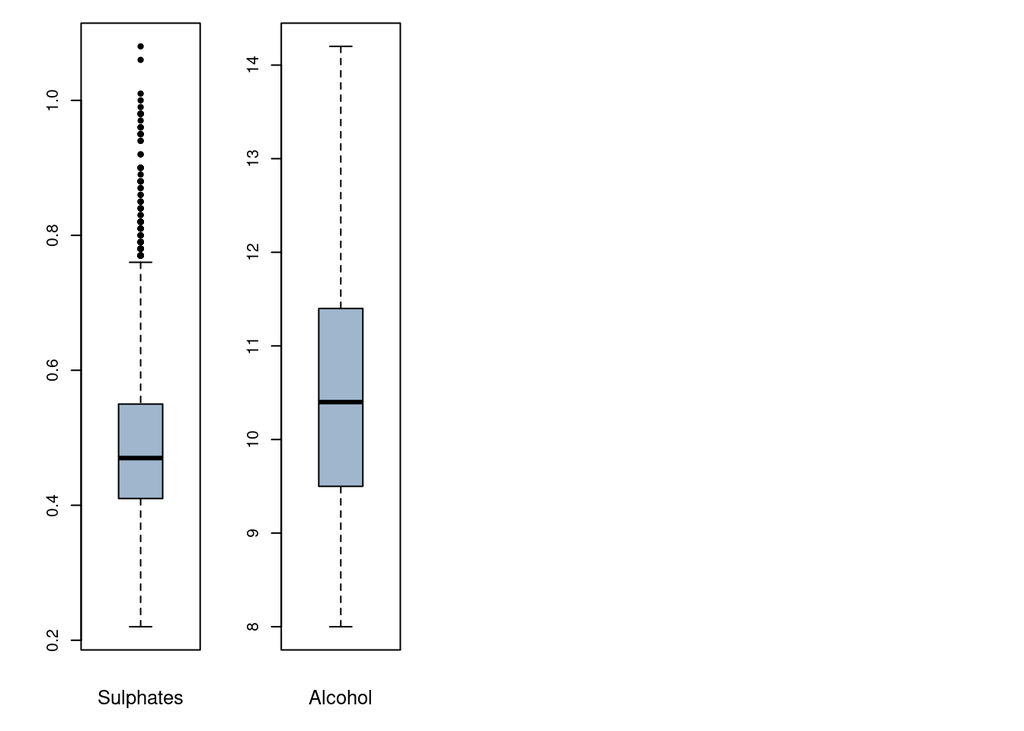

## Observations

# Summary Statistics and Correlations

For this section, we utilize the `psych` package. It is a general purpose toolbox for experimental psychology. However, we are more so interested in the package’s functions for multivariate analyses and scale construction using various analysis. For more information, visit [CRAN - Package psych](https://cran.r-project.org/web/packages/psych/index.html).

The observations with `psych::describe()` correlates with summary statistics.

```r
summary(white_wine)
```

```
##  fixed_acidity    volatile_acidity  citric_acid     residual_sugar
##  Min.   : 3.800   Min.   :0.0800   Min.   :0.0000   Min.   : 0.600
##  1st Qu.: 6.300   1st Qu.:0.2100   1st Qu.:0.2700   1st Qu.: 1.700
##  Median : 6.800   Median :0.2600   Median :0.3200   Median : 5.200
##  Mean   : 6.855   Mean   :0.2782   Mean   :0.3342   Mean   : 6.391
##  3rd Qu.: 7.300   3rd Qu.:0.3200   3rd Qu.:0.3900   3rd Qu.: 9.900
##  Max.   :14.200   Max.   :1.1000   Max.   :1.6600   Max.   :65.800
##    chlorides       free_sulfur_dioxide total_sulfur_dioxide    density
##  Min.   :0.00900   Min.   :  2.00      Min.   :  9.0        Min.   :0.9871
##  1st Qu.:0.03600   1st Qu.: 23.00      1st Qu.:108.0        1st Qu.:0.9917
##  Median :0.04300   Median : 34.00      Median :134.0        Median :0.9937
##  Mean   :0.04577   Mean   : 35.31      Mean   :138.4        Mean   :0.9940
##  3rd Qu.:0.05000   3rd Qu.: 46.00      3rd Qu.:167.0        3rd Qu.:0.9961
##  Max.   :0.34600   Max.   :289.00      Max.   :440.0        Max.   :1.0390
##        ph          sulphates         alcohol         quality
##  Min.   :2.720   Min.   :0.2200   Min.   : 8.00   Min.   :3.000
##  1st Qu.:3.090   1st Qu.:0.4100   1st Qu.: 9.50   1st Qu.:5.000
##  Median :3.180   Median :0.4700   Median :10.40   Median :6.000
##  Mean   :3.188   Mean   :0.4898   Mean   :10.51   Mean   :5.878
##  3rd Qu.:3.280   3rd Qu.:0.5500   3rd Qu.:11.40   3rd Qu.:6.000
##  Max.   :3.820   Max.   :1.0800   Max.   :14.20   Max.   :9.000
```

```r
psych::describe(white_wine)
```

|  | vars | n | mean | sd | median | trimmed | mad | min | max | range | skew | kurtosis | se |
| --- | --- | --- | --- | --- | --- | --- | --- | --- | --- | --- | --- | --- | --- |
| fixed_acidity | 1 | 4898 | 6.85478767 | 0.843868228 | 6.80000 | 6.81656888 | 0.741300000 | 3.80000 | 14.20000 | 10.40000 | 0.6473548 | 2.1666266 | 1.205772e-02 |
| volatile_acidity | 2 | 4898 | 0.27824112 | 0.100794548 | 0.26000 | 0.26747704 | 0.088956000 | 0.08000 | 1.10000 | 1.02000 | 1.5760137 | 5.0819038 | 1.440216e-03 |
| citric_acid | 3 | 4898 | 0.33419151 | 0.121019804 | 0.32000 | 0.32596173 | 0.088956000 | 0.00000 | 1.66000 | 1.66000 | 1.2811353 | 6.1636313 | 1.729207e-03 |
| residual_sugar | 4 | 4898 | 6.39141486 | 5.072057784 | 5.20000 | 5.80460459 | 5.337360000 | 0.60000 | 65.80000 | 65.20000 | 1.0764341 | 3.4624147 | 7.247276e-02 |
| chlorides | 5 | 4898 | 0.04577236 | 0.021847968 | 0.04300 | 0.04294566 | 0.010378200 | 0.00900 | 0.34600 | 0.33700 | 5.0202543 | 37.5084932 | 3.121775e-04 |
| free_sulfur_dioxide | 6 | 4898 | 35.30808493 | 17.007137325 | 34.00000 | 34.35918367 | 16.308600000 | 2.00000 | 289.00000 | 287.00000 | 1.4058834 | 11.4475147 | 2.430087e-01 |
| total_sulfur_dioxide | 7 | 4898 | 138.36065741 | 42.498064554 | 134.00000 | 136.95510204 | 42.995400000 | 9.00000 | 440.00000 | 431.00000 | 0.3904706 | 0.5685873 | 6.072391e-01 |
| density | 8 | 4898 | 0.99402738 | 0.002990907 | 0.99374 | 0.99392762 | 0.003172764 | 0.98711 | 1.03898 | 0.05187 | 0.9771742 | 9.7773683 | 4.273596e-05 |
| ph | 9 | 4898 | 3.18826664 | 0.151000600 | 3.18000 | 3.18239541 | 0.148260000 | 2.72000 | 3.82000 | 1.10000 | 0.4575022 | 0.5275677 | 2.157592e-03 |
| sulphates | 10 | 4898 | 0.48984688 | 0.114125834 | 0.47000 | 0.47990306 | 0.103782000 | 0.22000 | 1.08000 | 0.86000 | 0.9765952 | 1.5862080 | 1.630702e-03 |

[output cut: 2 more lines]

- Range is much larger compared to IQR.
- Mean is usually greater than the median.

These observations solidifies the existence of outliers, thus before any analysis is performed, the outliers must be taken care of.

Next, we look at bivariate analysis, including all pairwise scatterplot and correlation coefficients. Since our observations indicate a non-normal distribution, we consider using the Pearson correlation and Spearman Rank correlation.

### Table: Pearson’s Correlation

```r
stats::cor(white_wine[, -12])
```

```
##                      fixed_acidity volatile_acidity citric_acid residual_sugar
## fixed_acidity           1.00000000      -0.02269729  0.28918070     0.08902070
## volatile_acidity       -0.02269729       1.00000000 -0.14947181     0.06428606
## citric_acid             0.28918070      -0.14947181  1.00000000     0.09421162
## residual_sugar          0.08902070       0.06428606  0.09421162     1.00000000
## chlorides               0.02308564       0.07051157  0.11436445     0.08868454
## free_sulfur_dioxide    -0.04939586      -0.09701194  0.09407722     0.29909835
## total_sulfur_dioxide    0.09106976       0.08926050  0.12113080     0.40143931
## density                 0.26533101       0.02711385  0.14950257     0.83896645
## ph                     -0.42585829      -0.03191537 -0.16374821    -0.19413345
## sulphates              -0.01714299      -0.03572815  0.06233094    -0.02666437
## alcohol                -0.12088112       0.06771794 -0.07572873    -0.45063122
##                        chlorides free_sulfur_dioxide total_sulfur_dioxide
## fixed_acidity         0.02308564       -0.0493958591          0.091069756
## volatile_acidity      0.07051157       -0.0970119393          0.089260504
## citric_acid           0.11436445        0.0940772210          0.121130798
## residual_sugar        0.08868454        0.2990983537          0.401439311
## chlorides             1.00000000        0.1013923521          0.198910300
## free_sulfur_dioxide   0.10139235        1.0000000000          0.615500965
## total_sulfur_dioxide  0.19891030        0.6155009650          1.000000000
## density               0.25721132        0.2942104109          0.529881324
## ph                   -0.09043946       -0.0006177961          0.002320972
## sulphates             0.01676288        0.0592172458          0.134562367
## alcohol              -0.36018871       -0.2501039415         -0.448892102
##                          density            ph   sulphates     alcohol
## fixed_acidity         0.26533101 -0.4258582910 -0.01714299 -0.12088112
## volatile_acidity      0.02711385 -0.0319153683 -0.03572815  0.06771794
## citric_acid           0.14950257 -0.1637482114  0.06233094 -0.07572873
## residual_sugar        0.83896645 -0.1941334540 -0.02666437 -0.45063122
## chlorides             0.25721132 -0.0904394560  0.01676288 -0.36018871
## free_sulfur_dioxide   0.29421041 -0.0006177961  0.05921725 -0.25010394
## total_sulfur_dioxide  0.52988132  0.0023209718  0.13456237 -0.44889210
## density               1.00000000 -0.0935914935  0.07449315 -0.78013762
## ph                   -0.09359149  1.0000000000  0.15595150  0.12143210
## sulphates             0.07449315  0.1559514973  1.00000000 -0.01743277
## alcohol              -0.78013762  0.1214320987 -0.01743277  1.00000000
```

### Table: Spearman Rank Correlation

```r
stats::cor(white_wine[, -12], method = "spearman")
```

```
##                      fixed_acidity volatile_acidity citric_acid residual_sugar
## fixed_acidity           1.00000000     -0.042865228  0.29787793     0.10672494
## volatile_acidity       -0.04286523      1.000000000 -0.15040998     0.10862744
## citric_acid             0.29787793     -0.150409981  1.00000000     0.02462098
## residual_sugar          0.10672494      0.108627441  0.02462098     1.00000000
## chlorides               0.09469118     -0.004934156  0.03265950     0.22784390
## free_sulfur_dioxide    -0.02454223     -0.081212903  0.08831406     0.34610674
## total_sulfur_dioxide    0.11264866      0.117613959  0.09321867     0.43125248
## density                 0.27003091      0.010124341  0.09142519     0.78036485
## ph                     -0.41834116     -0.045203569 -0.14619267    -0.18002822
## sulphates              -0.01323781     -0.016902303  0.07976628    -0.00384398
## alcohol                -0.10682740      0.033966554 -0.02916996    -0.44525743
##                         chlorides free_sulfur_dioxide total_sulfur_dioxide
## fixed_acidity         0.094691176        -0.024542230           0.11264866
## volatile_acidity     -0.004934156        -0.081212903           0.11761396
## citric_acid           0.032659495         0.088314056           0.09321867
## residual_sugar        0.227843904         0.346106737           0.43125248
## chlorides             1.000000000         0.167045505           0.37524367
## free_sulfur_dioxide   0.167045505         1.000000000           0.61861634
## total_sulfur_dioxide  0.375243666         0.618616339           1.00000000
## density               0.508301765         0.327821798           0.56382409
## ph                   -0.054006467        -0.006273578          -0.01182872
## sulphates             0.093930696         0.052251683           0.15782480
## alcohol              -0.570806407        -0.272569338          -0.47661933
##                          density           ph   sulphates     alcohol
## fixed_acidity         0.27003091 -0.418341158 -0.01323781 -0.10682740
## volatile_acidity      0.01012434 -0.045203569 -0.01690230  0.03396655
## citric_acid           0.09142519 -0.146192675  0.07976628 -0.02916996
## residual_sugar        0.78036485 -0.180028223 -0.00384398 -0.44525743
## chlorides             0.50830177 -0.054006467  0.09393070 -0.57080641
## free_sulfur_dioxide   0.32782180 -0.006273578  0.05225168 -0.27256934
## total_sulfur_dioxide  0.56382409 -0.011828718  0.15782480 -0.47661933
## density               1.00000000 -0.110060852  0.09507867 -0.82185508
## ph                   -0.11006085  1.000000000  0.14024331  0.14885725
## sulphates             0.09507867  0.140243305  1.00000000 -0.04486799
## alcohol              -0.82185508  0.148857249 -0.04486799  1.00000000
```

- `Total Sulfur Dioxide`
- `Density`
- `pH`
- `Alcohol`

### Scatterplot of predictors

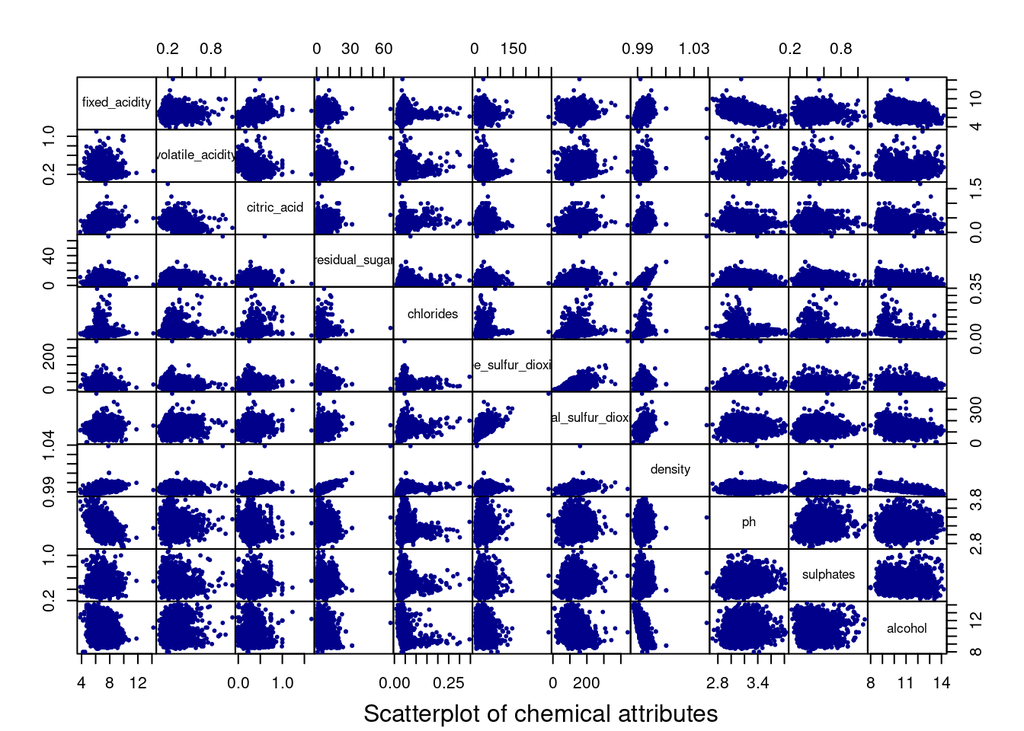

```r
graphics::pairs(white_wine[, -12], gap = 0, pch = 19, cex = 0.4, col = "darkblue")
title(sub = "Scatterplot of chemical attributes", cex = 0.8)
```

# Data Preparation

Possibly the most important step in data preparation is to identify outliers. Since we have a multivariate data, we consider only those points which do not have any predictore variable value to be outside of limits constructed by boxplots. Therefore, we apply the following rule:

- A predictor value is considered to be an outlier only if it is greater than Q3 + 1.5IQR, where Q3 is the third quartile and we multiple the `Inner Quartile Range` by 1.5.

This is because the extreme outliers are all on the higher end of the values and the distributions are all positively skewed.

We then randomly divide our data into Training Data and Test Data of equal sizes (50% each).

```r
limit_out <- rep(0, 11)

for (i in 1:11) {
  tile1 <- stats::quantile(white_wine[,i], 0.75)
  tile2 <- stats::IQR(white_wine[,i], 0.75)
  limit_out[i] <- tile1 + 1.5*tile2
}

WhiteWineIndex <- matrix(0, 4898, 11)
for (i in 1:4898)
  for (j in 1:11) {
    if (white_wine[i, j] > limit_out[j])
      WhiteWineIndex[i, j] <- 1
  }
WWInd <- apply(WhiteWineIndex, 1, sum)
WhiteWineTemp <- cbind(WWInd, white_wine)
Indexes <- rep(0, 208)
j <- 1
for (i in 1:4898) {
  if (WWInd[i] > 0) {
    Indexes[j] <- i
    j <- j + 1
  }
  else
    j <- j
}

WhiteWineLib <- white_wine[-Indexes, ]   # Inside of Q3+1.5IQR
indexes = sample(1:nrow(WhiteWineLib), size = 0.5 * nrow(WhiteWineLib))
white_wine_train <- WhiteWineLib[indexes, ]
white_wine_test <- WhiteWineLib[-indexes, ]

white_wine_train %>%
  saveRDS(here::here("data", "white_wine_train.rds"))
white_wine_test %>%
  saveRDS(here::here("data", "white_wine_test.rds"))
```

# Looking for our model

Linear Regression is fitted to the training data.

We also look at the Variance Inflation Factor (VIF) to detect multicollinearity in regression analysis. Multicollinearity is when there’s correlation between predictors in a model; it’s presence can adveresly affect the regression results. The VIF estimates how much the variance of a regression coefficient is inflated due to multicollinearity in the model.

## Model 1: All predictors

```r
fitness_1 <- stats::lm(quality ~ ., data = white_wine_train)
summary(fitness_1)
```

```
##
## Call:
## stats::lm(formula = quality ~ ., data = white_wine_train)
##
## Residuals:
##     Min      1Q  Median      3Q     Max
## -3.4377 -0.5261 -0.0366  0.4647  2.4664
##
## Coefficients:
##                        Estimate Std. Error t value Pr(>|t|)
## (Intercept)           2.459e+02  3.753e+01   6.550 7.25e-11 ***
## fixed_acidity         1.610e-01  3.781e-02   4.258 2.16e-05 ***
## volatile_acidity     -1.857e+00  2.271e-01  -8.178 5.05e-16 ***
## citric_acid           1.560e-01  1.973e-01   0.791   0.4293
## residual_sugar        1.155e-01  1.404e-02   8.228 3.38e-16 ***
## chlorides            -2.557e+00  2.022e+00  -1.265   0.2061
## free_sulfur_dioxide   2.501e-03  1.489e-03   1.680   0.0932 .
## total_sulfur_dioxide  8.146e-04  6.138e-04   1.327   0.1846
## density              -2.476e+02  3.803e+01  -6.510 9.43e-11 ***
## ph                    1.127e+00  1.833e-01   6.146 9.52e-10 ***
## sulphates             7.185e-01  1.761e-01   4.080 4.68e-05 ***
## alcohol               6.994e-02  4.785e-02   1.462   0.1440
## ---
## Signif. codes:  0 '***' 0.001 '**' 0.01 '*' 0.05 '.' 0.1 ' ' 1
##
## Residual standard error: 0.7363 on 2025 degrees of freedom
## Multiple R-squared:  0.2572, Adjusted R-squared:  0.2531
## F-statistic: 63.73 on 11 and 2025 DF,  p-value: < 2.2e-16
```

```r
regclass::VIF(fitness_1)
```

```
##        fixed_acidity     volatile_acidity          citric_acid
##             3.035871             1.162039             1.138519
##       residual_sugar            chlorides  free_sulfur_dioxide
##            18.307519             1.554326             1.820316
## total_sulfur_dioxide              density                   ph
##             2.378569            46.735912             2.419713
##            sulphates              alcohol
##             1.152136            12.825755
```

For extremely high VIF, `density` is removed from the model. There are other predictors with high VIF, but they are not removed from the model.

## Model 2: After removal of density VIFs improved

```r
fitness_2 <-
  stats::step(stats::lm(quality ~ 1, white_wine_train),
                         scope = list(lower = ~ 1,
                                      upper = ~ fixed_acidity +
                                        volatile_acidity + citric_acid + residual_sugar +
                                        chlorides + free_sulfur_dioxide + ph + sulphates +
                                        alcohol),
                         direction = "forward")
```

```
## Start:  AIC=-651.46
## quality ~ 1
##
##                       Df Sum of Sq    RSS      AIC
## + alcohol              1   267.325 1210.7 -1055.86
## + chlorides            1   116.880 1361.1  -817.27
## + residual_sugar       1    18.664 1459.3  -675.34
## + volatile_acidity     1    16.434 1461.6  -672.23
## + ph                   1    12.732 1465.3  -667.08
## + fixed_acidity        1     8.245 1469.8  -660.85
## + citric_acid          1     1.702 1476.3  -651.80
## <none>                             1478.0  -651.46
## + sulphates            1     0.005 1478.0  -649.46
## + free_sulfur_dioxide  1     0.002 1478.0  -649.46
##
## Step:  AIC=-1055.86
## quality ~ alcohol
##
##                       Df Sum of Sq    RSS     AIC
## + volatile_acidity     1    38.828 1171.8 -1120.3
## + residual_sugar       1    22.153 1188.5 -1091.5
## + free_sulfur_dioxide  1    19.224 1191.4 -1086.5
## + chlorides            1     4.064 1206.6 -1060.7
## + sulphates            1     2.717 1208.0 -1058.4
## + ph                   1     2.511 1208.2 -1058.1
## + citric_acid          1     1.580 1209.1 -1056.5
## + fixed_acidity        1     1.436 1209.2 -1056.3
## <none>                             1210.7 -1055.9
##
## Step:  AIC=-1120.26
## quality ~ alcohol + volatile_acidity
##
##                       Df Sum of Sq    RSS     AIC
## + residual_sugar       1   31.5650 1140.3 -1173.9
## + free_sulfur_dioxide  1   17.6604 1154.2 -1149.2
## + chlorides            1    2.9092 1168.9 -1123.3
## + sulphates            1    2.4089 1169.4 -1122.5
## + fixed_acidity        1    2.2298 1169.6 -1122.1
## + ph                   1    2.1965 1169.6 -1122.1
## <none>                             1171.8 -1120.3
```

[output cut: 39 more lines]

```
##
##                 Df Sum of Sq    RSS     AIC
## + sulphates      1   2.74483 1121.5 -1199.7
## <none>                       1124.2 -1196.7
## + fixed_acidity  1   0.31753 1123.9 -1195.3
## + citric_acid    1   0.01228 1124.2 -1194.8
##
## Step:  AIC=-1199.71
## quality ~ alcohol + volatile_acidity + residual_sugar + free_sulfur_dioxide +
##     ph + chlorides + sulphates
##
##                 Df Sum of Sq    RSS     AIC
## <none>                       1121.5 -1199.7
## + fixed_acidity  1   0.51578 1121.0 -1198.7
## + citric_acid    1   0.00067 1121.5 -1197.7
```

```r
summary(fitness_2)
```

```
##
## Call:
## stats::lm(formula = quality ~ alcohol + volatile_acidity + residual_sugar +
##     free_sulfur_dioxide + ph + chlorides + sulphates, data = white_wine_train)
##
## Residuals:
##     Min      1Q  Median      3Q     Max
## -3.2478 -0.5261 -0.0319  0.4502  2.4868
##
## Coefficients:
##                      Estimate Std. Error t value Pr(>|t|)
## (Intercept)          1.216918   0.461381   2.638 0.008414 **
## alcohol              0.357819   0.018514  19.327  < 2e-16 ***
## volatile_acidity    -1.944715   0.217485  -8.942  < 2e-16 ***
## residual_sugar       0.028072   0.004151   6.763 1.76e-11 ***
## free_sulfur_dioxide  0.004037   0.001210   3.337 0.000862 ***
## ph                   0.368912   0.123044   2.998 0.002749 **
## chlorides           -5.150494   1.983197  -2.597 0.009470 **
## sulphates            0.375705   0.168596   2.228 0.025961 *
## ---
## Signif. codes:  0 '***' 0.001 '**' 0.01 '*' 0.05 '.' 0.1 ' ' 1
##
## Residual standard error: 0.7435 on 2029 degrees of freedom
## Multiple R-squared:  0.2412, Adjusted R-squared:  0.2386
## F-statistic: 92.14 on 7 and 2029 DF,  p-value: < 2.2e-16
```

```r
regclass::VIF(fitness_2)
```

```
##             alcohol    volatile_acidity      residual_sugar free_sulfur_dioxide
##            1.883324            1.045095            1.568580            1.178279
##                  ph           chlorides           sulphates
##            1.069566            1.467344            1.035990
```

## Model 3: Working model

```r
fitness_3 <-
  stats::lm(quality ~ alcohol + volatile_acidity + residual_sugar + free_sulfur_dioxide +
              sulphates + chlorides + ph, data = white_wine_train)
summary(fitness_3)
```

```
##
## Call:
## stats::lm(formula = quality ~ alcohol + volatile_acidity + residual_sugar +
##     free_sulfur_dioxide + sulphates + chlorides + ph, data = white_wine_train)
##
## Residuals:
##     Min      1Q  Median      3Q     Max
## -3.2478 -0.5261 -0.0319  0.4502  2.4868
##
## Coefficients:
##                      Estimate Std. Error t value Pr(>|t|)
## (Intercept)          1.216918   0.461381   2.638 0.008414 **
## alcohol              0.357819   0.018514  19.327  < 2e-16 ***
## volatile_acidity    -1.944715   0.217485  -8.942  < 2e-16 ***
## residual_sugar       0.028072   0.004151   6.763 1.76e-11 ***
## free_sulfur_dioxide  0.004037   0.001210   3.337 0.000862 ***
## sulphates            0.375705   0.168596   2.228 0.025961 *
## chlorides           -5.150494   1.983197  -2.597 0.009470 **
## ph                   0.368912   0.123044   2.998 0.002749 **
## ---
## Signif. codes:  0 '***' 0.001 '**' 0.01 '*' 0.05 '.' 0.1 ' ' 1
##
## Residual standard error: 0.7435 on 2029 degrees of freedom
## Multiple R-squared:  0.2412, Adjusted R-squared:  0.2386
## F-statistic: 92.14 on 7 and 2029 DF,  p-value: < 2.2e-16
```

```r
regclass::VIF(fitness_3)
```

```
##             alcohol    volatile_acidity      residual_sugar free_sulfur_dioxide
##            1.883324            1.045095            1.568580            1.178279
##           sulphates           chlorides                  ph
##            1.035990            1.467344            1.069566
```

```r
graphics::par(mfrow = c(1, 2), oma = c(3, 2, 3, 2) + 0.1, mar = c(1, 1, 1, 1) + 0.1)
MASS::truehist(stats::residuals(fitness_3), h = 0.25, col = "slategray3")

# quantile-comparison plot
car::qqPlot(stats::residuals(fitness_3),
            pch = 19,
            col = "darkblue",
            cex = 0.6,
            ylab = "Fitness 3 residuals")
```

```
## 1230  446
##   23 1957
```

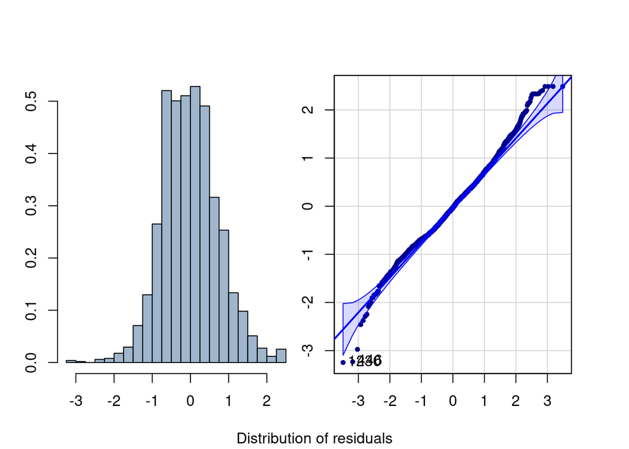

```r
graphics::mtext("Distribution of residuals", outer = T, side = 1, line = 2)
```

```r
graphics::par(mfrow = c(1, 1))
```

Residuals have an approximately symmetric distribution but there seems to be outliers at both ends. Partial residual plots are examined. Note the patterns in the fitted value plot. Since the response actually takes only integer values but has been assumed to be continuous, such pattern arises.

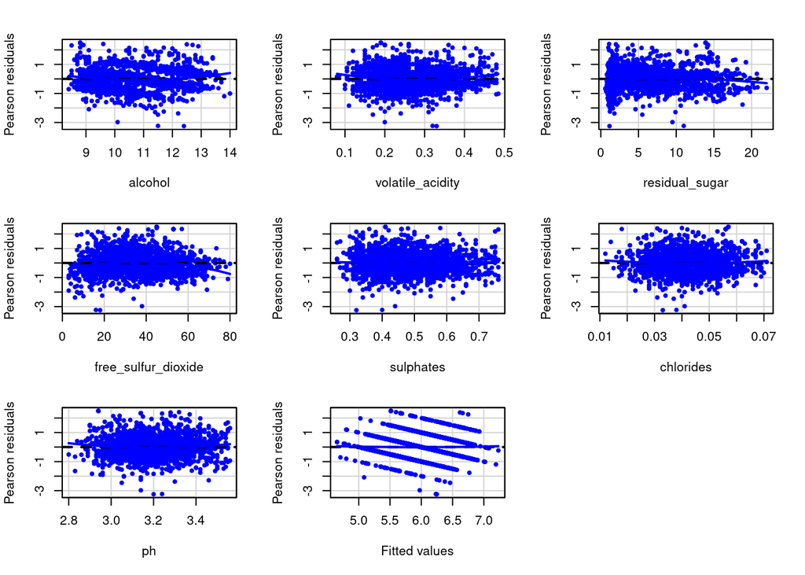

```
##                     Test stat Pr(>|Test stat|)
## alcohol                4.6953        2.841e-06 ***
## volatile_acidity       4.8133        1.594e-06 ***
## residual_sugar        -2.7105         0.006774 **
## free_sulfur_dioxide   -7.6594        2.873e-14 ***
## sulphates              0.9660         0.334165
## chlorides              1.7208         0.085437 .
## ph                     2.9191         0.003549 **
## Tukey test             0.5882         0.556426
## ---
## Signif. codes:  0 '***' 0.001 '**' 0.01 '*' 0.05 '.' 0.1 ' ' 1
```

```r
# Pearson residuals
car::residualPlots(fitness_3, pch = 19, col = "blue", cex = 0.6)
```

We also investigate the Box-Cox plot

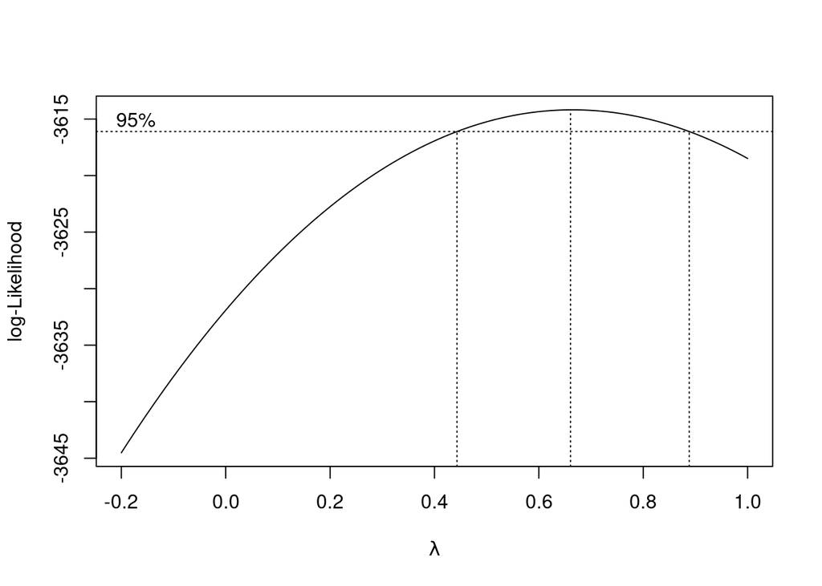

```r
MASS::boxcox(stats::lm(quality ~ alcohol),
             data = white_wine_train, lambda = seq(-0.2, 1.0, len = 20),
             plotit = T)
```

Outliers and leverage points are identified through the following:

- Studentized deleted residuals - a point is an outlier if residual is outside of [-3, 3] limits
- DFITS - a point is an outlier if residual is outside of [-1, 1] limits
- Cook’s Distance

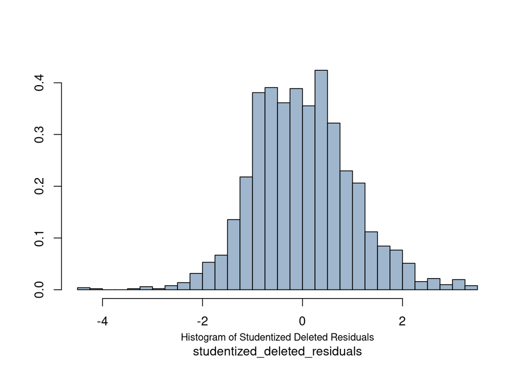

```r
studentized_deleted_residuals <- MASS::studres(fitness_3)
MASS::truehist(studentized_deleted_residuals, h = 0.25, col = "slategray3")
graphics::mtext("Histogram of Studentized Deleted Residuals", side = 1, line = 2, cex = 0.8)
```

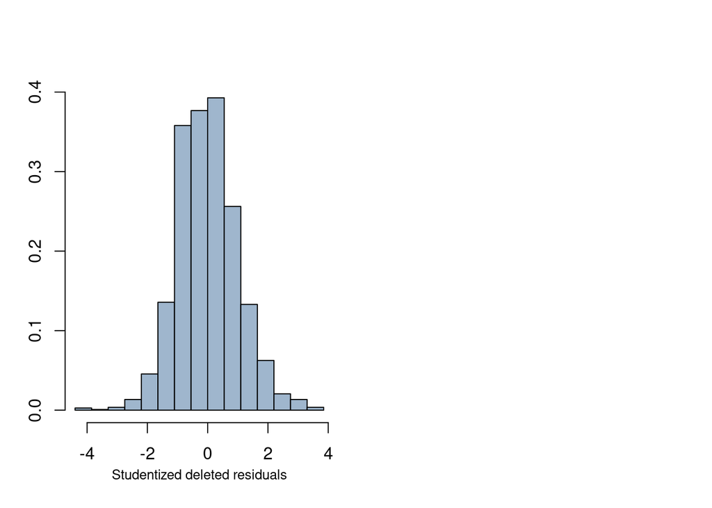

```r
# Larger bin width
graphics::par(mfrow=c(1,2), oma = c(3,2,3,2) + 0.1, mar = c(1,1,1,1) + 0.1)
MASS::truehist(studentized_deleted_residuals, h = 0.55, col = "slategray3")
graphics::mtext("Studentized deleted residuals", side = 1, line = 2, cex = 0.8)
```

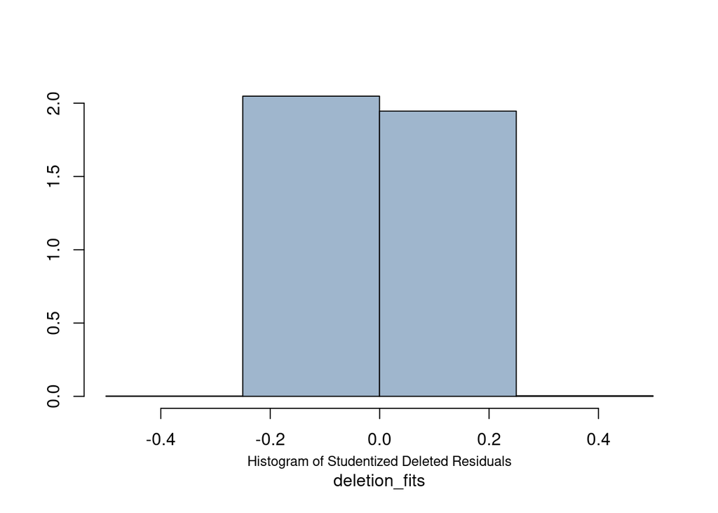

```r
deletion_fits <- stats::dffits(fitness_3)
MASS::truehist(deletion_fits, h = 0.25, col = "slategray3")
graphics::mtext("Histogram of Studentized Deleted Residuals", side = 1, line = 2, cex = 0.8)
```

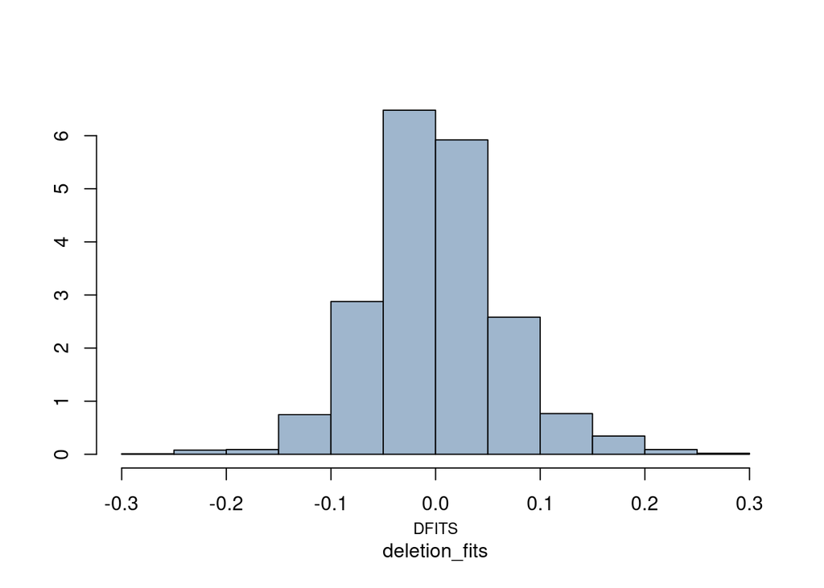

```r
# Smaller bin width
MASS::truehist(deletion_fits, h = 0.05, col = "slategray3")
graphics::mtext("DFITS", side = 1, line = 2, cex = 0.8)
```

No point is an outlier with the DFITS value.

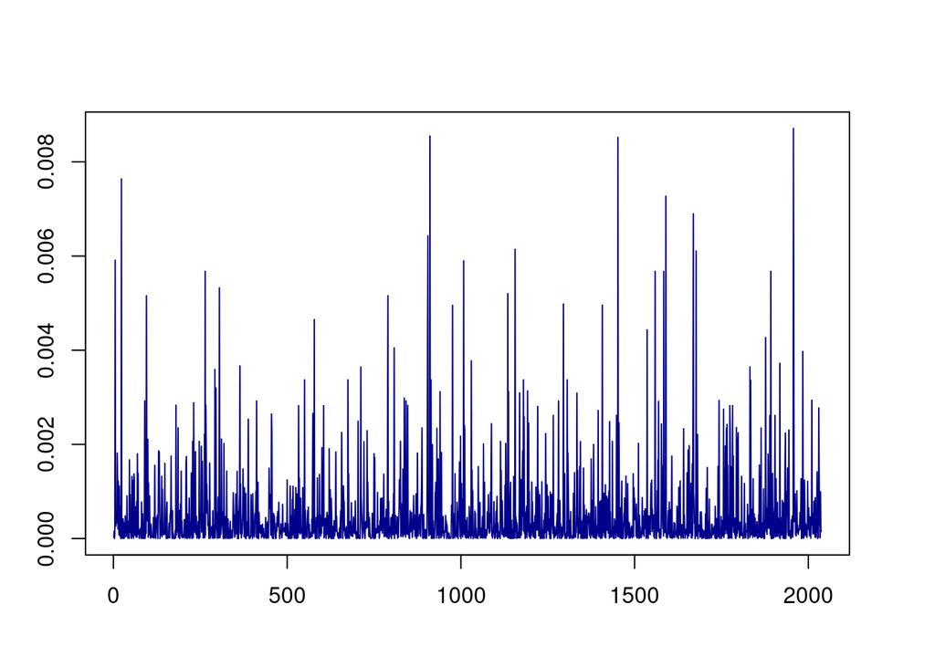

```r
cooks_dist <- stats::cooks.distance(fitness_3)
graphics::par(mfrow=c(1,1), oma = c(3,2,3,2) + 0.1, mar = c(1,1,1,1) + 0.1)
stats::ts.plot(cooks_dist, col = "dark blue")
```

## Final Model

```r
final_model <- stats::lm(quality ~ stats::poly(alcohol, 2) + stats::poly(volatile_acidity, 2) + residual_sugar
                         + stats::poly(free_sulfur_dioxide, 2) + chlorides + sulphates + stats::poly(ph, 2),
                         white_wine_train)
summary(final_model)
```

```
##
## Call:
## stats::lm(formula = quality ~ stats::poly(alcohol, 2) + stats::poly(volatile_acidity,
##     2) + residual_sugar + stats::poly(free_sulfur_dioxide, 2) +
##     chlorides + sulphates + stats::poly(ph, 2), data = white_wine_train)
##
## Residuals:
##      Min       1Q   Median       3Q      Max
## -3.13851 -0.52120 -0.00442  0.44270  2.39519
##
## Coefficients:
##                                       Estimate Std. Error t value Pr(>|t|)
## (Intercept)                           5.839361   0.115792  50.430  < 2e-16 ***
## stats::poly(alcohol, 2)1             18.407725   1.013554  18.162  < 2e-16 ***
## stats::poly(alcohol, 2)2              3.290261   0.781707   4.209 2.68e-05 ***
## stats::poly(volatile_acidity, 2)1    -6.734010   0.759093  -8.871  < 2e-16 ***
## stats::poly(volatile_acidity, 2)2     3.380742   0.734915   4.600 4.48e-06 ***
## residual_sugar                        0.021706   0.004227   5.136 3.08e-07 ***
## stats::poly(free_sulfur_dioxide, 2)1  3.059115   0.790509   3.870 0.000112 ***
## stats::poly(free_sulfur_dioxide, 2)2 -5.547400   0.734563  -7.552 6.45e-14 ***
## chlorides                            -5.723615   1.939707  -2.951 0.003206 **
## sulphates                             0.443925   0.164754   2.694 0.007108 **
## stats::poly(ph, 2)1                   2.109509   0.752150   2.805 0.005085 **
## stats::poly(ph, 2)2                   1.706002   0.734803   2.322 0.020347 *
## ---
## Signif. codes:  0 '***' 0.001 '**' 0.01 '*' 0.05 '.' 0.1 ' ' 1
##
## Residual standard error: 0.725 on 2025 degrees of freedom
## Multiple R-squared:  0.2798, Adjusted R-squared:  0.2759
## F-statistic: 71.52 on 11 and 2025 DF,  p-value: < 2.2e-16
```

```r
final_model %>%
  saveRDS(here::here("data", "white_white_model.rds"))
```

A slight improvement in the **R<sup>2</sup>** value is noted.

# Application of Model to Test Data

We apply our model to the test data.

```r
prediction <- stats::predict(final_model, white_wine_test)
summary(prediction)
```

```
##    Min. 1st Qu.  Median    Mean 3rd Qu.    Max.
##   4.692   5.600   5.895   5.930   6.218   7.583
```